# HW_Lesson_3

### Урок 3. Классификация. Логистическая регрессия.

```python
import numpy as np
import matplotlib.pyplot as plt
```

```python
X = np.array([[1, 1, 1, 1, 1, 1, 1, 1, 1, 1],
              [1, 1, 2, 5, 3, 0, 5, 10, 1, 2],
              [500, 700, 750, 600, 1450, 800, 1500, 2000, 450, 1000],
              [1, 1, 2, 1, 2,  1, 3, 3, 1, 2]], dtype = np.float64)
y = np.array([0, 0, 1, 0, 1, 0, 1, 0, 1, 1], dtype = np.float64)
```

```python
X
```

```
array([[1.00e+00, 1.00e+00, 1.00e+00, 1.00e+00, 1.00e+00, 1.00e+00,
        1.00e+00, 1.00e+00, 1.00e+00, 1.00e+00],
       [1.00e+00, 1.00e+00, 2.00e+00, 5.00e+00, 3.00e+00, 0.00e+00,
        5.00e+00, 1.00e+01, 1.00e+00, 2.00e+00],
       [5.00e+02, 7.00e+02, 7.50e+02, 6.00e+02, 1.45e+03, 8.00e+02,
        1.50e+03, 2.00e+03, 4.50e+02, 1.00e+03],
       [1.00e+00, 1.00e+00, 2.00e+00, 1.00e+00, 2.00e+00, 1.00e+00,
        3.00e+00, 3.00e+00, 1.00e+00, 2.00e+00]])
```

```python
y
```

```
array([0., 0., 1., 0., 1., 0., 1., 0., 1., 1.])
```

```python
def calc_std_feat(x):
    res = (x - x.mean()) / x.std()
    return res
```

```python
X_st = X.copy()
X_st[2, :] = calc_std_feat(X[2, :])
```

```python
X_st
```

```
array([[ 1.        ,  1.        ,  1.        ,  1.        ,  1.        ,
         1.        ,  1.        ,  1.        ,  1.        ,  1.        ],
       [ 1.        ,  1.        ,  2.        ,  5.        ,  3.        ,
         0.        ,  5.        , 10.        ,  1.        ,  2.        ],
       [-0.97958969, -0.56713087, -0.46401617, -0.77336028,  0.97958969,
        -0.36090146,  1.08270439,  2.11385144, -1.08270439,  0.05155735],
       [ 1.        ,  1.        ,  2.        ,  1.        ,  2.        ,
         1.        ,  3.        ,  3.        ,  1.        ,  2.        ]])
```

```python
def calc_logloss(y, y_pred):
    err = - np.mean(y * np.log(y_pred) + (1.0 - y) * np.log(1.0 - y_pred))
    err = np.sum(err)
    return err
```

```python
# Пример применения
y1 = np.array([1, 0])
y_pred1 = np.array([0.9, 0.1])
calc_logloss(y1, y_pred1)
```

```
0.10536051565782628
```

```python
def sigmoid(z):
    res = 1 / (1 + np.exp(-z))
    return res
```

```python
z = np.linspace(-10, 10, 101)
```

```python
probabilities = sigmoid(z)
```

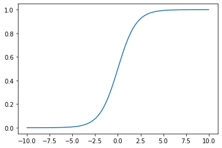

```python
plt.plot(z, probabilities)
plt.show()
```

Logistic Regression

```python
def eval_model(X, y, iterations, alpha=1e-4):
    np.random.seed(42)
    W = np.random.randn(X.shape[0])
    n = X.shape[1]
    for i in range(1, iterations+1):
        z = np.dot(W, X)
        y_pred = sigmoid(z)
        err = calc_logloss(y, y_pred)
        W -= alpha * (1/n * np.dot((y_pred - y), X.T))
        if i % (iterations / 10) == 0:
            print(i, W, err)
    return W
```

```python
W = eval_model(X_st, y, iterations=5000, alpha=1e-4)
```

```
500 [ 0.47822106 -0.20918419  0.64605995  1.49531432] 1.0559639161585663
1000 [ 0.46074241 -0.27647603  0.64395686  1.46891696] 0.945214871179169
1500 [ 0.44435675 -0.33951515  0.64152026  1.44406912] 0.8478360281905125
2000 [ 0.42913461 -0.39751872  0.63899625  1.42106251] 0.7651177745022372
2500 [ 0.41513888 -0.44956784  0.63671032  1.40023024] 0.6981293270105476
3000 [ 0.40240136 -0.49488241  0.63498247  1.38184975] 0.6468813805442176
3500 [ 0.39088925 -0.53321212  0.63401986  1.36601535] 0.6097021563515639
4000 [ 0.38049869 -0.56497213  0.63387116  1.35259671] 0.5836774145473647
4500 [ 0.37108342 -0.59102182  0.63446603  1.3413119 ] 0.5657147376221167
5000 [ 0.36249064 -0.61234585  0.63568321  1.33183158] 0.5532737788236779
```

## Д/з

1*. Измените функцию calc_logloss так, чтобы нули по возможности не попадали в np.log.

1. Подберите аргументы функции eval_model для логистической регрессии таким образом, чтобы log loss был минимальным.
2. Создайте функцию calc_pred_proba, возвращающую предсказанную вероятность класса 1 (на вход подаются W, который уже посчитан функцией eval_model и X, на выходе - массив y_pred_proba).
3. Создайте функцию calc_pred, возвращающую предсказанный класс (на вход подаются W, который уже посчитан функцией eval_model и X, на выходе - массив y_pred).
4. Посчитайте Accuracy, матрицу ошибок, точность и полноту, а также F1 score.
5. Могла ли модель переобучиться? Почему?

## Задача 1

1*. Измените функцию calc_logloss так, чтобы нули по возможности не попадали в np.log.

```python
def calc_logloss_zeros(y, y_pred):
    err_sum = []
    for i in range(len(y_pred)):
        if y_pred[i] != 0 and y_pred[i] != 1:
            err_sum.append(y[i] * np.log(y_pred[i]) + (1.0 - y[i]) * np.log(1.0 - y_pred[i]))
        elif y[i] != y_pred[i]:
            err_sum.append(-1)
        else:
            err_sum.append(0)
    err = -np.mean(err_sum)
    err = np.sum(err)
    return err
```

```python
y1 = np.array([1, 0])
y_pred1 = np.array([0.9, 0.1])
calc_logloss_zeros(y1, y_pred1)
```

```
0.10536051565782628
```

## Задача 2

Подберите аргументы функции eval_model для логистической регрессии таким образом, чтобы log loss был минимальным.

```python
np.random.seed(42)
```

```python
def eval_model_min_err(X, y, iterations, alpha):
    dist = np.inf
    eps = 1e-8
    W = np.random.randn(X.shape[0])
    n = X.shape[1]
    for i in range(1, iterations+1):
        z = np.dot(W, X)
        y_pred = sigmoid(z)
        # Сразу будем использовать новую функцию потерь
        err = calc_logloss_zeros(y, y_pred)
        W -= alpha * (1/n * np.dot((y_pred - y), X.T))
        if i % 100000 == 0:
            print(i, W, err, alpha)
        # Будем постепенно уменьшать альфа, проверяя значение ошибки
        # Совсем мальнькую альфа брать не будем
        if err < 0.001:
            if alpha > 1e-2:
                alpha = alpha*0.5
        # Если значение ошибки уменьшается незначительно - выходим из цикла
        if abs(dist - err) < eps:
            print(i, W, err, alpha)
            break
        dist = err
    return W
```

```python
W = eval_model_min_err(X_st, y, iterations=1000000, alpha=25)
```

```
100000 [-290.75587919  -19.95192671  -86.6149952   221.42710881] 0.002360249509429783 25
149536 [-313.59225633  -21.3775496   -93.53731531  238.55106954] 0.0016547167309318926 25
```

# Задача 3

Создайте функцию calc_pred_proba, возвращающую предсказанную вероятность класса 1 (на вход подаются W, который уже посчитан функцией eval_model и X, на выходе - массив y_pred_proba).ь

$$P_+(y = 1|W, X) = sigmoid(\langle W, X \rangle)$$

где $$sigmoid = f(z) = \frac{1}{1+\exp^{-z}}$$

```python
def calc_pred_proba(W, X):
    return sigmoid(W @ X)
```

```python
calc_pred_proba(W, X_st)
```

```
array([8.23946114e-03, 1.45977111e-19, 1.00000000e+00, 2.54261767e-48,
       9.99569031e-01, 1.17715318e-18, 1.00000000e+00, 7.95908441e-05,
       9.92267234e-01, 1.00000000e+00])
```

## Задача 4

Создайте функцию calc_pred, возвращающую предсказанный класс (на вход подаются W, который уже посчитан функцией eval_model и X, на выходе - массив y_pred).

Используем преведущую функцию, просто окгруглив вероятность принадлежности к классу

```python
def calc_pred(W, X):
    return np.round(calc_pred_proba(W, X), 0)
```

```python
y_pred = calc_pred(W, X_st)
y_pred
```

```
array([0., 0., 1., 0., 1., 0., 1., 0., 1., 1.])
```

## Задача 5

Посчитайте Accuracy, матрицу ошибок, точность и полноту, а также F1 score.

$$ Accuracy = \frac{TP+TN}{TP+FP+TN+FN} $$

Построим Таблицу сопряженности

```python
err_matrix = np.zeros((2, 2))
for i in range(len(y)):
    if y_pred[i] == 1 and y[i] == 1:
        err_matrix[0][0] += 1
    elif y_pred[i] == 1 and y[i] == 0:
        err_matrix[0][1] += 1
    elif y_pred[i] == 0 and y[i] == 1:
        err_matrix[1][0] += 1
    else:
        err_matrix[1][1] += 1
err_matrix
```

```
array([[5., 0.],
       [0., 5.]])
```

Видим, что наш классификатор работает правильно, и не допускает ошибок

```python
def accuracy(M):
    return((M[0][0] + M[1][1])/np.sum(M))
```

```python
accuracy(err_matrix)
```

```
1.0
```

*Ответ* $accuracy = 1$

$$precision = \frac{TP}{TP + FP}$$

```python
def precision(M):
    return((M[0][0])/(M[0][0]+M[1][0]))
```

```python
precision(err_matrix)
```

```
1.0
```

*Ответ* $precision = 1$

$$recall = \frac{TP}{TP + FN}$$

```python
def recall(M):
    return((M[0][0])/(M[0][0]+M[0][1]))
```

```python
recall(err_matrix)
```

```
1.0
```

*Ответ* $recall = 1$

$$ F = \frac{2 * precision * recall}{precision + recall}$$

```python
def F(M):
    return((2*precision(M) * recall(M))/(precision(M)+recall(M)))
```

```python
F(err_matrix)
```

```
1.0
```

*Ответ* $Fm = 1$

# Задача 6